# Simple Tests

## Exercise

- one sample influence on means: show mean value and test if it is different than a population mean value
- one sample influence on propotions: show propotion and test if it is different than a population propotion
- two-sample influence on means (independant): show mean value of two groups and test if they are different
- two-sample influence on propotions (independant): show propotion of two groups and test if they are different

```r
#Get Titanic data
library(Hmisc)
getHdata(titanic3)
head(titanic3)
```

```
##   pclass survived                            name    sex     age sibsp parch
## 1    1st        1   Allen, Miss. Elisabeth Walton female 29.0000     0     0
## 2    1st        1  Allison, Master. Hudson Trevor   male  0.9167     1     2
## 3    1st        0    Allison, Miss. Helen Loraine female  2.0000     1     2
## 4    1st        0 Allison, Mr. Hudson Joshua Crei   male 30.0000     1     2
## 5    1st        0 Allison, Mrs. Hudson J C (Bessi female 25.0000     1     2
## 6    1st        1             Anderson, Mr. Harry   male 48.0000     0     0
##   ticket     fare   cabin    embarked boat body                       home.dest
## 1  24160 211.3375      B5 Southampton    2   NA                    St Louis, MO
## 2 113781 151.5500 C22 C26 Southampton   11   NA Montreal, PQ / Chesterville, ON
## 3 113781 151.5500 C22 C26 Southampton        NA Montreal, PQ / Chesterville, ON
## 4 113781 151.5500 C22 C26 Southampton       135 Montreal, PQ / Chesterville, ON
## 5 113781 151.5500 C22 C26 Southampton        NA Montreal, PQ / Chesterville, ON
## 6  19952  26.5500     E12 Southampton    3   NA                    New York, NY
```

```r
dataForAnalysis=titanic3
```

## one sample influence on means: show mean value and test if it is different than a population mean value

### What’s the mean age in titanic data? Is it different than 30, which is the median Age of US at 1950

show *Mean age and SD*

```r
mean(dataForAnalysis$age,na.rm=TRUE)
```

```
## [1] 29.88113
```

```r
sd(dataForAnalysis$age,na.rm=TRUE)
```

```
## [1] 14.4135
```

Distribution

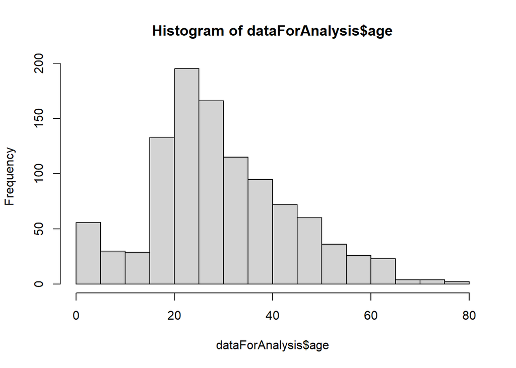

```r
hist(dataForAnalysis$age)
```

```r
#one sample t test
t.test(dataForAnalysis$age,mu=30)
```

```
##
##  One Sample t-test
##
## data:  dataForAnalysis$age
## t = -0.26672, df = 1045, p-value = 0.7897
## alternative hypothesis: true mean is not equal to 30
## 95 percent confidence interval:
##  29.00664 30.75562
## sample estimates:
## mean of x
##  29.88113
```